# Filtros.03-Projeto

O nosso objetivo é o de limpar as imagens do cameraman com ruido e comparar com a original.

Original

Ruido

Ruido2

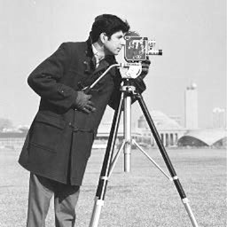

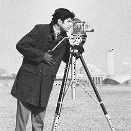

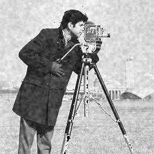

Temos o sinal (imagem), devemos construir o grafo. Primeiro, construir um grafo simples, i.e. com peso unitário, conectando um pixel com os oito imediatamente próximos.

Filtrar com: heat (com diferentes parámetros); regularização à Tikhonov. Podem usar as versões já implementadas no PyGSP, mas podem tentar implementar as suas.

Comparar a qualidade da imagem filtrada com a original usando 3 métricas: 1) olho nu; 2) erro quadrático medio (MSE); 3) peak signal-to-noise ratio (PSNR). As métricas 2) e 3) estão descritas na Wikipedia em https://en.wikipedia.org/wiki/Peak_signal-to-noise_ratio Existem implementações das duas métricas em alguns módulos Python, procurar ou implementá- las.

Em caso que implementem algum filtro, comparem a performance do tempo de execução (como mostrado na aula de hoje) com o da implementação do PyGSP.

Agora, vamos a construir outro grafo, seguindo a sugestão de Shuman et al, IEEE Signals Processing Magazine 2013 (Example 2, pag. 90). Em outras palabras, construir um grafo com peso, onde o peso leva em conta o "gradiente de cinza" da imagem.

Como antes, filtrar com: heat (com diferentes parámetros); regularização à Tikhonov.

**Entrega:** *Jupyter ou .py com código usado. Discutir resultados. Uma tabela comparando os valores obtidos nas diferentes métricas é desejável.* **Prazo: flexivel, mas sem abusar**